# Tarea 13

Shanthal Chavarría

2020-11-11

# Pregunta 1: [30 puntos]

En esta pregunta utiliza los datos (tumores.csv). Se trata de un conjunto de datos de características del tumor cerebral que incluye cinco variables de primer orden y ocho de textura y cuatro parámetros de evaluación de la calidad con el nivel objetivo. La variables son: Media, Varianza, Desviación estándar, Asimetría, Kurtosis, Contraste, Energía, ASM (segundo momento angular), Entropía, Homogeneidad, Disimilitud, Correlación, Grosor, PSNR (Pico de la relación señal-ruido), SSIM (Indice de Similitud Estructurada), MSE (Mean Square Error), DC (Coeficiente de Dados) y la variable a predecir tipo (1 = Tumor, 0 = No-Tumor).

Realice lo siguiente:

## 1. Cargue la tabla de datos tumores.csv en R y ejecute un str(…), summary(…) y un dim(…), verifique la correcta lectura de los datos.

```r
library(caret)
library(dplyr)
library(MASS)
library(traineR)

tumores <- read.table("Datos Tarea/tumores_V2.csv", sep = ",", dec = ".", header = TRUE, stringsAsFactors = TRUE)[,-1]
dim(tumores)
```

```
[1] 1275   17
```

```r
str(tumores)
```

```
'data.frame':   1275 obs. of  17 variables:
 $ media              : num  23.45 4.4 3.24 8.51 21 ...
 $ varianza           : num  2539 835 642 1126 2235 ...
 $ desviacion.estandar: num  50.4 28.9 25.3 33.6 47.3 ...
 $ entropia           : num  0.651 0.954 0.966 0.869 0.685 ...
 $ asimetria          : num  1.98 6.5 7.77 3.76 1.94 ...
 $ kurtosis           : num  5.42 43.35 61.76 15.11 4.72 ...
 $ contraste          : num  181.5 76.7 81.8 362.3 312.4 ...
 $ energia            : num  0.782 0.973 0.98 0.922 0.804 ...
 $ asm                : num  0.611 0.946 0.961 0.85 0.647 ...
 $ homogeneidad       : num  0.847 0.981 0.985 0.949 0.88 ...
 $ disiminitud        : num  2.765 0.549 0.54 2.766 3.007 ...
 $ correlacion        : num  0.969 0.96 0.944 0.859 0.939 ...
 $ psnr               : num  98 110.3 112.3 102 97.6 ...
 $ ssim               : num  0.777 0.978 0.985 0.881 0.766 ...
 $ mse                : num  0.17116 0.00991 0.00637 0.06844 0.18488 ...
 $ dc                 : num  0.304 0.839 0.85 0 0 ...
 $ tipo               : Factor w/ 2 levels "No","Si": 2 2 2 1 1 1 2 2 2 2 ...
```

```r
summary(tumores)
```

```
     media              varianza        desviacion.estandar    entropia
 Min.   : 0.001541   Min.   :   0.156   Min.   : 0.3945     Min.   :0.5307
 1st Qu.: 0.381950   1st Qu.:  58.557   1st Qu.: 7.6523     1st Qu.:0.9326
 Median : 1.826401   Median : 280.429   Median :16.7460     Median :0.9757
 Mean   : 4.029659   Mean   : 486.384   Mean   :18.3179     Mean   :0.9344
   asimetria          kurtosis          contraste           energia
 Min.   :  1.219   Min.   :    2.50   Min.   :  0.3557   Min.   :0.6959
 1st Qu.:  5.437   1st Qu.:   30.57   1st Qu.: 20.7866   1st Qu.:0.9603
 Median :  9.377   Median :   88.95   Median : 50.4217   Median :0.9858
 Mean   : 16.996   Mean   :  742.22   Mean   : 75.0515   Mean   :0.9600
      asm          homogeneidad     disiminitud        correlacion
 Min.   :0.4843   Min.   :0.8111   Min.   :0.003522   Min.   :-0.0000349
 1st Qu.:0.9223   1st Qu.:0.9730   1st Qu.:0.150540   1st Qu.: 0.8308350
 Median :0.9718   Median :0.9895   Median :0.415167   Median : 0.9001476
 Mean   :0.9257   Mean   :0.9739   Mean   :0.704138   Mean   : 0.8650773
      psnr             ssim             mse                  dc
 Min.   : 53.38   Min.   :0.6760   Min.   :0.0002257   Min.   :0.00000
 1st Qu.: 62.04   1st Qu.:0.9369   1st Qu.:0.0118142   1st Qu.:0.08947
 Median : 64.94   Median :0.9612   Median :0.0235417   Median :0.36098
 Mean   : 68.90   Mean   :0.9395   Mean   :0.0424071   Mean   :0.38858
 tipo
 No:  97
 Si:1178


 [ reached getOption("max.print") -- omitted 2 rows ]
```

## 2.

El objetivo de este ejercicio es analizar la variación del error (usando el enfoque training- testing) para la predicción de variable tipo (que indica 1 = Tumor, 0 = No-Tumor), para esto repita 5 veces el cálculo de error global de predicción usando el método de los k vecinos más cercanos (use kmax=50) y con un 75% de los datos para tabla aprendizaje y un 25 % para la tabla testing. Grafique los resultados.

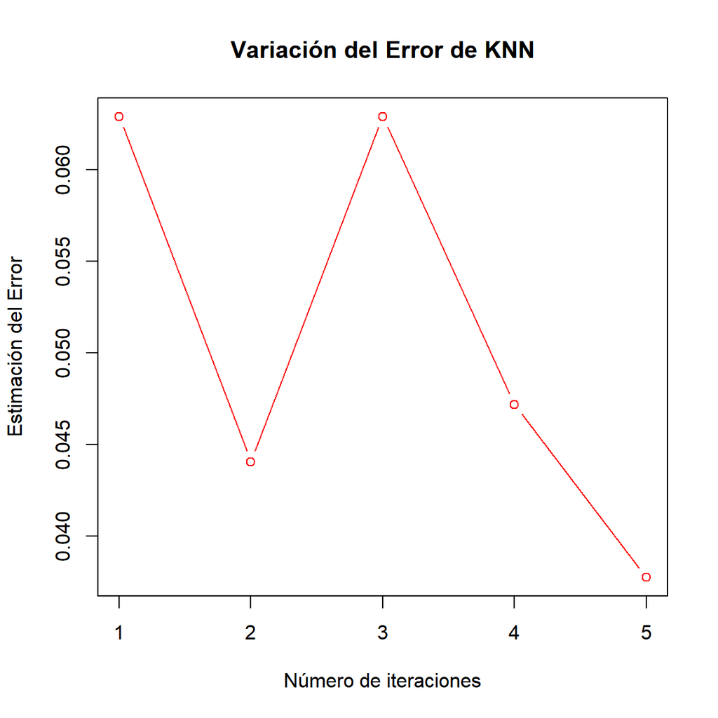

```r
v.error.tt <- rep(0,5)

for (i in 0:5) {
  #genero las tablas de aprendizaje y testing
  p <- createDataPartition(tumores$tipo, p = 0.75, list = FALSE)

  ttesting <- tumores[-p,]
  taprendizaje <- tumores[p,]

  modelo <- train.knn(tipo~.,taprendizaje, kmax = 50)

  prediccion <- predict(modelo, ttesting)

  MC <- confusion.matrix(ttesting,prediccion)

  #Precisión Global (De todos los valores el porcentaje que predijo bien)
  acierto <- sum(diag(MC)/sum(MC))
  # error global
  error <- 1 - acierto

  #agrego el error al vector
  v.error.tt[i] <- error
}

#gráfico el error

plot(v.error.tt, col = "red", type = "b", main = "Variación del Error de KNN", xlab = "Número de iteraciones", ylab = "Estimación del Error")
```

## 3.

El objetivo de este ejercicio es medir el error para la predicción de variable tipo, utilizando validación cruzada con K grupos (K−fold cross-validation). Para esto usando el método de los k vecinos más cercanos (use kmax=50) realice una validación cruzada 5 veces con 10 grupos (folds) y grafique el error obtenido en cada iteración, agregue en este gráfico los 5 errores generados en el ejercicio anterior.

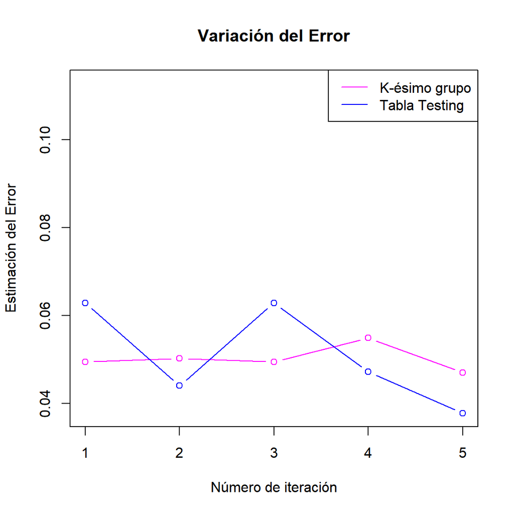

```r
library(caret)
n <- dim(tumores)[1]

v.error.kg <- rep(0,5)


#Hacemos validación cruzada 5 veces
for (i in 1:5) {
  errori <- 0
  #se generan los 10 grupos
  grupos <- createFolds(1:n,10)

  #ciclo que empieza a hacer validación cruzada con 10 grupos
  for (k in 1:10) {

    muestra <- grupos[[k]]
    ttesting <- tumores[muestra,]
    taprendizaje <- tumores[-muestra,]

    modelo <- train.knn(tipo~., taprendizaje, kmax = 50)

    prediccion <- predict(modelo, ttesting)

    MC <- confusion.matrix(ttesting, prediccion)

    #precisión global
    acierto <- sum(diag(MC))/sum(MC)
    error <- 1 - acierto
    #suma los errores de cada grupo
    errori <- errori + error

  }
  #promedia el error
  v.error.kg[i]  <- errori/10
}

plot(v.error.kg, col = "magenta", type = "b", ylim = c(min(v.error.kg,v.error.tt), max(v.error.kg,v.error.tt) + 0.05), main = "Variación del Error", xlab = "Número de iteración",
    ylab = "Estimación del Error")
points(v.error.tt, col = "blue", type = "b")
legend("topright", legend = c("K-ésimo grupo","Tabla Testing"), col = c("magenta",
    "blue"), lty = 1, lwd = 1)
```

# Ejercicio 2: [25 puntos]

Para esta pregunta también usaremos los datos tumores.csv.

## 1.

El objetivo de este ejercicio es calibrar el método de ADA para esta Tabla de Datos. Aquí interesa predecir en la variable tipo. Para esto genere 5 Validaciones Cruzadas con 10 grupos calibrando el modelo de acuerdo con los tres tipos de algoritmos que permite, discrete, real y gentle. Para medir la calidad de método sume la cantidad de 1’s detectados en los diferentes grupos. Luego grafique las 5 iteraciones para los tres algoritmos en el mismo gráfico. ¿Se puede determinar con claridad cuál algoritmo es el mejor? Para generar los modelos predictivos use las siguientes instrucciones:

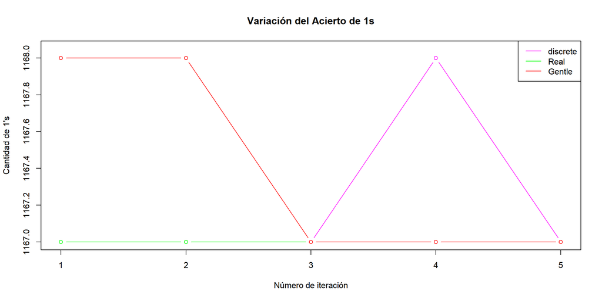

```r
n <- dim(tumores)[1]

## Vamos a generar el modelo dejando un grupo para testing y los demás datos para aprendizaje.
cantidad1.1 <- rep(1:5)
cantidad1.2 <- rep(1:5)
cantidad1.3 <- rep(1:5)

# Hacemos validación cruzada 5 veces para ver que el error se estabiliza
for(i in 1:5) {
  matrizTotal.1 <- 0
  matrizTotal.2<- 0
  matrizTotal.3 <- 0

  # Esta instrucción genera los k=10 grupos (Folds)
  grupos <- createFolds(1:n,10) # grupos$Fold0i es el i-ésimo grupo
  # Este ciclo es el que hace "cross-validation" (validación cruzada) con 10 grupos (Folds)
  for(k in 1:10) {
      muestra <- grupos[[k]] # Por ser una lista requiere de doble paréntesis
      ttesting <- tumores[muestra,]
      taprendizaje <- tumores[-muestra,]

      modelo1<-train.ada(tipo~.,data=taprendizaje,iter=80,nu=1,type="discrete")
      modelo2<-train.ada(tipo~.,data=taprendizaje,iter=80,nu=1,type="real")
      modelo3<-train.ada(tipo~.,data=taprendizaje,iter=80,nu=1,type="gentle")



      prediccion1 <- predict(modelo1,ttesting,type = "class")
      prediccion2 <- predict(modelo2,ttesting,type = "class")
      prediccion3 <- predict(modelo3,ttesting,type = "class")

      MC.1 <- confusion.matrix(ttesting, prediccion1)
      MC.2 <- confusion.matrix(ttesting, prediccion2)
      MC.3 <- confusion.matrix(ttesting, prediccion3)



      # Sumatoria de todas las matrices de confusión

      matrizTotal.1 <- matrizTotal.1 + MC.1
      matrizTotal.2<- matrizTotal.2 + MC.2
      matrizTotal.3 <- matrizTotal.3 + MC.3
  }

  #cantidad de 1s total para cada iteración
  cantidad1.1[i] <- matrizTotal.1[4]
  cantidad1.2[i] <- matrizTotal.2[4]
  cantidad1.3[i] <- matrizTotal.3[4]

}


plot(cantidad1.1, col = "magenta", type = "b", ylim = c(min(cantidad1.1, cantidad1.2,cantidad1.3), max(cantidad1.1, cantidad1.2, cantidad1.3) + 0.05), main = "Variación del Acierto de 1s", xlab = "Número de iteración", ylab = "Cantidad de 1's")
points(cantidad1.2, col = "green", type = "b")
points(cantidad1.3, col = "red", type = "b")
legend("topright", legend = c("discrete","Real","Gentle"), col = c("magenta","green","red"), lty = 1, lwd = 1)
```

## 2.

Repita el ejercicio anterior, pero esta vez en lugar de sumar la cantidad de 1’s, promedie los errores globales cometidos en los diferentes grupos (folds). Luego grafique las 5 iteraciones para los tres algoritmos en el mismo gráfico. ¿Se puede determinar con claridad cuál algoritmo es el mejor?

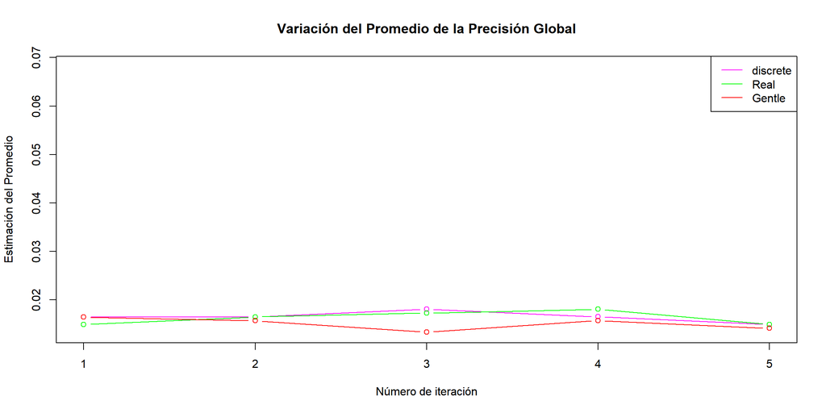

```r
n <- dim(tumores)[1]

## Vamos a generar el modelo dejando un grupo para testing y los demás datos para aprendizaje.
pg.1 <- rep(1:5)
pg.2 <- rep(1:5)
pg.3 <- rep(1:5)

# Hacemos validación cruzada 5 veces para ver que el error se estabiliza
for(i in 1:5) {
  #vectores que tendran las precisiones globales de cada grupo
  v.pg1 <- 0
  v.pg2<- 0
  v.pg3 <- 0

  # Esta instrucción genera los k=10 grupos (Folds)
  grupos <- createFolds(1:n,10) # grupos$Fold0i es el i-ésimo grupo
  # Este ciclo es el que hace "cross-validation" (validación cruzada) con 10 grupos (Folds)
  for(k in 1:10) {
      muestra <- grupos[[k]] # Por ser una lista requiere de doble paréntesis
      ttesting <- tumores[muestra,]
      taprendizaje <- tumores[-muestra,]

      modelo1<-train.ada(tipo~.,data=taprendizaje,iter=80,nu=1,type="discrete")
      modelo2<-train.ada(tipo~.,data=taprendizaje,iter=80,nu=1,type="real")
      modelo3<-train.ada(tipo~.,data=taprendizaje,iter=80,nu=1,type="gentle")


      prediccion1 <- predict(modelo1,ttesting,type = "class")
      prediccion2 <- predict(modelo2,ttesting,type = "class")
      prediccion3 <- predict(modelo3,ttesting,type = "class")

      MC.1 <- confusion.matrix(ttesting, prediccion1)
      MC.2 <- confusion.matrix(ttesting, prediccion2)
      MC.3 <- confusion.matrix(ttesting, prediccion3)

      #Precisión Global (De todos los valores el porcentaje que predijo bien)
      acierto1 <- sum(diag(MC.1)/sum(MC.1))
      acierto2 <- sum(diag(MC.2)/sum(MC.2))
      acierto3 <- sum(diag(MC.3)/sum(MC.3))

      #error global
      v.pg1[k] <- 1 - acierto1
      v.pg2[k] <- 1 - acierto2
      v.pg3[k] <- 1 - acierto3
  }

  #promedio total del error global para cada iteración
  pg.1[i] <- mean(v.pg1)
  pg.2[i] <- mean(v.pg2)
  pg.3[i] <- mean(v.pg3)

}


plot(pg.1, col = "magenta", type = "b", ylim = c(min(pg.1, pg.2,pg.3), max(pg.1, pg.2, pg.3) + 0.05), main = "Variación del Promedio de la Precisión Global", xlab = "Número de iteración", ylab = "Estimación del Promedio")
points(pg.2, col = "green", type = "b")
points(pg.3, col = "red", type = "b")
legend("topright", legend = c("discrete","Real","Gentle"), col = c("magenta","green","red"), lty = 1, lwd = 1)
```

## 3.

Para estar realmente seguros de cuál de los tipos algoritmos es mejor, modifique (una en uno solo código) los códigos de los dos ejercicios anteriores de manera que, en lugar de sumar la cantidad de 1’s detectados y de promediar los errores globales, guarde en cada iteración (en listas) las matrices de confusión de cada uno de los 3 algoritmos. Luego al final de los ciclos ejecutados para cada algoritmo calcule una Matriz de Confusión Promedio de todas las matrices de confusión guardadas en la lista del respectivo algoritmo; así con estas Matrices de Confusión Promedio, mediante gráficos de barras, determine el método que en promedio detecta mayor porcentaje de 1’s, determine el método que en promedio detecta mayor porcentaje de 0’s y determine el método que en promedio tiene menor error global.

### Matrices Promedio

```r
n <- dim(tumores)[1]

## Vamos a generar el modelo dejando un grupo para testing y los demás datos para aprendizaje.
mc.1 <- 0
mc.2 <- 0
mc.3 <- 0

# Hacemos validación cruzada 5 veces para ver que el error se estabiliza
for(i in 1:5) {
  matrizTotal.1 <- 0
  matrizTotal.2<- 0
  matrizTotal.3 <- 0

  # Esta instrucción genera los k=10 grupos (Folds)
  grupos <- createFolds(1:n,10) # grupos$Fold0i es el i-ésimo grupo
  # Este ciclo es el que hace "cross-validation" (validación cruzada) con 10 grupos (Folds)
  for(k in 1:10) {
      muestra <- grupos[[k]] # Por ser una lista requiere de doble paréntesis
      ttesting <- tumores[muestra,]
      taprendizaje <- tumores[-muestra,]

      modelo1<-train.ada(tipo~.,data=taprendizaje,iter=80,nu=1,type="discrete")
      modelo2<-train.ada(tipo~.,data=taprendizaje,iter=80,nu=1,type="real")
      modelo3<-train.ada(tipo~.,data=taprendizaje,iter=80,nu=1,type="gentle")



      prediccion1 <- predict(modelo1,ttesting,type = "class")
      prediccion2 <- predict(modelo2,ttesting,type = "class")
      prediccion3 <- predict(modelo3,ttesting,type = "class")

      MC.1 <- confusion.matrix(ttesting, prediccion1)
      MC.2 <- confusion.matrix(ttesting, prediccion2)
      MC.3 <- confusion.matrix(ttesting, prediccion3)



      # Sumatoria de todas las matrices de confusión

      matrizTotal.1 <- matrizTotal.1 + MC.1
      matrizTotal.2<- matrizTotal.2 + MC.2
      matrizTotal.3 <- matrizTotal.3 + MC.3
  }

  #Matriz Total para cada iteración
  mc.1 <- mc.1 + matrizTotal.1
  mc.2 <- mc.2 + matrizTotal.2
  mc.3 <- mc.3 + matrizTotal.3

}

#Matriz de Confusion Promedio

mc.pr.1 <- mc.1/5
mc.pr.2 <- mc.2/5
mc.pr.3 <- mc.3/5


#Error global Promedio
err.pr.1 <- 1-  sum(diag(mc.pr.1)/sum(mc.pr.1))
err.pr.2 <- 1- sum(diag(mc.pr.2)/sum(mc.pr.2))
err.pr.3 <- 1 -sum(diag(mc.pr.3)/sum(mc.pr.3))
```

### Gráficos

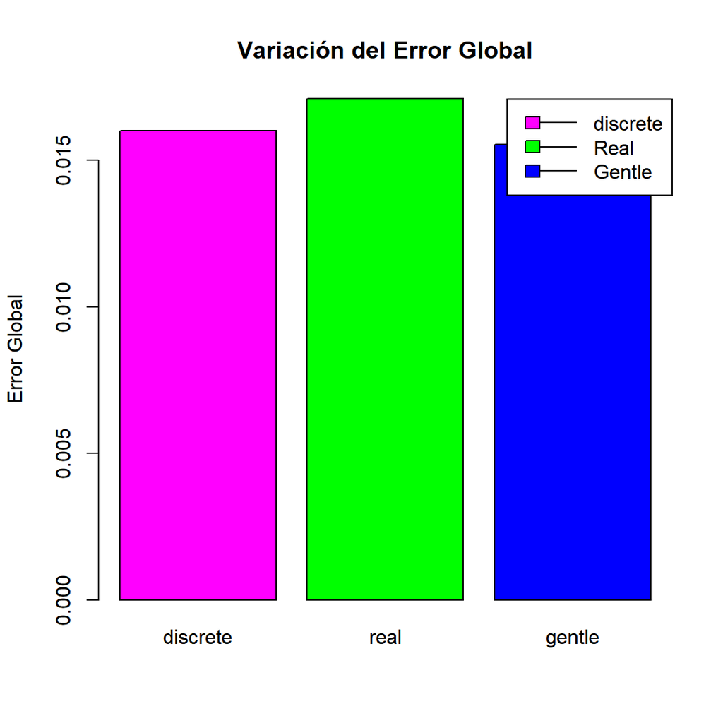

```r
error <- c(err.pr.1,err.pr.2,err.pr.3)
names(error)<- c("discrete", "real", "gentle")

barplot(error, ylim = c(0,max(error)), main = "Variación del Error Global", ylab = "Error Global", col = c("magenta","green","blue"))
legend("topright", legend = c("discrete","Real","Gentle"), fill= c("magenta","green","blue"), lty = 1, lwd = 1)
```

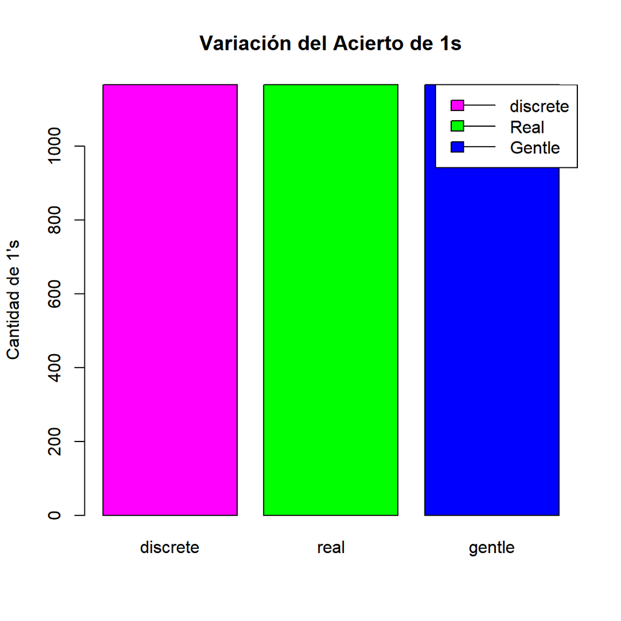

```r
cantidad1 <- c(mc.pr.1[4],mc.pr.2[4],mc.pr.3[4])
names(cantidad1)<- c("discrete", "real", "gentle")

barplot(cantidad1, ylim = c(0,max(cantidad1)), main = "Variación del Acierto de 1s", ylab = "Cantidad de 1's", col = c("magenta","green","blue"))
legend("topright", legend = c("discrete","Real","Gentle"), fill= c("magenta","green","blue"), lty = 1, lwd = 1)
```

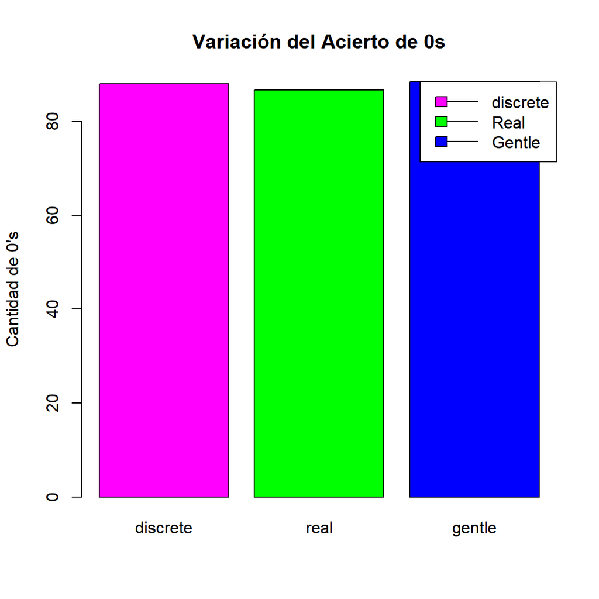

```r
cantidad0 <- c(mc.pr.1[1],mc.pr.2[1],mc.pr.3[1])
names(cantidad0)<- c("discrete", "real", "gentle")

barplot(cantidad0, ylim = c(0,max(cantidad0)), main = "Variación del Acierto de 0s", ylab = "Cantidad de 0's", col = c("magenta","green","blue"))
legend("topright", legend = c("discrete","Real","Gentle"), fill= c("magenta","green","blue"), lty = 1, lwd = 1)
```

## 4.

¿Cuál algoritmo usaría con base en la información obtenida en el ejercicio anterior?

```r
#minimo error
error[error == min(error)]
```

```
    gentle
0.01552941
```

```r
#maximo cantidad de 1s predichos
cantidad1[cantidad1 == max(cantidad1)]
```

```
gentle
1166.8
```

```r
#maximo cantidad de 0s predichos
cantidad0[cantidad0 == max(cantidad0)]
```

```
gentle
  88.4
```

# Ejercicio 3: [25 puntos]

Para esta pregunta usaremos nuevamente los datos tumores.csv.

## 1.

El objetivo de este ejercicio es calibrar el método de knn para esta Tabla de Datos. Aquí interesa predecir en la variable tipo. Para esto genere 5 Validaciones Cruzadas con 10 grupos calibrando el modelo de acuerdo con todos los tipos de algoritmos que permite train.kknn en el parámetro kernel, estos algoritmos son: rectangular, triangular, epanechnikov, biweight, triweight, cos, inv, gaussian y optimal. Para medir la calidad de método sume la cantidad de 1’s detectados en los diferentes grupos. Luego grafique las 5 iteraciones para todos algoritmos en el mismo gráfico. ¿Se puede determinar con claridad cuál algoritmo es el mejor?

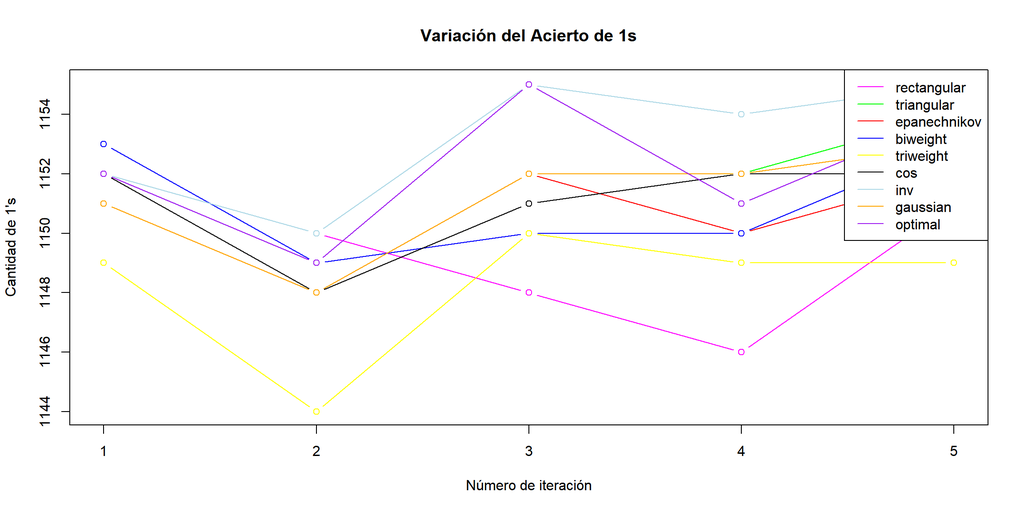

```r
n <- dim(tumores)[1]


cantidad1.1 <- rep(1:5)
cantidad1.2 <- rep(1:5)
cantidad1.3 <- rep(1:5)
cantidad1.4 <- rep(1:5)
cantidad1.5 <- rep(1:5)
cantidad1.6 <- rep(1:5)
cantidad1.7 <- rep(1:5)
cantidad1.8 <- rep(1:5)
cantidad1.9 <- rep(1:5)


# Hacemos validación cruzada 5 veces para ver que el error se estabiliza
for(i in 1:5) {
  matrizTotal.1 <- 0
  matrizTotal.2<- 0
  matrizTotal.3 <- 0
  matrizTotal.4 <- 0
  matrizTotal.5<- 0
  matrizTotal.6 <- 0
  matrizTotal.7 <- 0
  matrizTotal.8<- 0
  matrizTotal.9 <- 0
  matrizTotal.10 <- 0


  # Esta instrucción genera los k=10 grupos
  grupos <- createFolds(1:n,10) # grupos$Fold0i es el i-ésimo grupo
  # Este ciclo es el que hace "cross-validation" (validación cruzada) con 10 grupos (Folds)
  for(k in 1:10) {
      muestra <- grupos[[k]] # Por ser una lista requiere de doble paréntesis
      ttesting <- tumores[muestra,]
      taprendizaje <- tumores[-muestra,]

      modelo.rectangular <- train.knn(tipo~., data = taprendizaje, kernel = "rectangular")
      modelo.triangular <- train.knn(tipo~., data = taprendizaje, kernel = "triangular")
      modelo.epanechnikov <- train.knn(tipo~., data = taprendizaje, kernel = "epanechnikov")
      modelo.biweight <- train.knn(tipo~., data = taprendizaje, kernel = "biweight")
      modelo.triweight <- train.knn(tipo~., data = taprendizaje, kernel = "triweight")
      modelo.cos <- train.knn(tipo~., data = taprendizaje, kernel = "cos")
      modelo.inv <- train.knn(tipo~., data = taprendizaje, kernel = "inv")
      modelo.gaussian <- train.knn(tipo~., data = taprendizaje, kernel = "gaussian")
      modelo.optimal <- train.knn(tipo~., data = taprendizaje, kernel = "optimal")




      prediccion1 <- predict(modelo.rectangular,ttesting,type = "class")
      prediccion2 <- predict(modelo.triangular,ttesting,type = "class")
      prediccion3 <- predict(modelo.epanechnikov,ttesting,type = "class")
      prediccion4 <- predict(modelo.biweight,ttesting,type = "class")
      prediccion5 <- predict(modelo.triweight,ttesting,type = "class")
      prediccion6 <- predict(modelo.cos,ttesting, type = "class")
      prediccion7 <- predict(modelo.inv,ttesting,type = "class")
      prediccion8 <- predict(modelo.gaussian,ttesting,type = "class")
      prediccion9 <- predict(modelo.optimal,ttesting, type = "class")


      MC.1 <- confusion.matrix(ttesting, prediccion1)
      MC.2 <- confusion.matrix(ttesting, prediccion2)
      MC.3 <- confusion.matrix(ttesting, prediccion3)
      MC.4 <- confusion.matrix(ttesting, prediccion4)
      MC.5 <- confusion.matrix(ttesting, prediccion5)
      MC.6 <- confusion.matrix(ttesting, prediccion6)
      MC.7 <- confusion.matrix(ttesting, prediccion7)
      MC.8 <- confusion.matrix(ttesting, prediccion8)
      MC.9 <- confusion.matrix(ttesting, prediccion9)



      # Sumatoria de todas las matrices de confusión

      matrizTotal.1 <- matrizTotal.1 + MC.1
      matrizTotal.2<- matrizTotal.2 + MC.2
      matrizTotal.3 <- matrizTotal.3 + MC.3
      matrizTotal.4 <- matrizTotal.4 + MC.4
      matrizTotal.5<- matrizTotal.5 + MC.5
      matrizTotal.6 <- matrizTotal.6 + MC.6
      matrizTotal.7 <- matrizTotal.7 + MC.7
      matrizTotal.8<- matrizTotal.8 + MC.8
      matrizTotal.9 <- matrizTotal.9 + MC.9
  }

  #cantidad de 1s total para cada iteración
  cantidad1.1[i] <- matrizTotal.1[4]
  cantidad1.2[i] <- matrizTotal.2[4]
  cantidad1.3[i] <- matrizTotal.3[4]
  cantidad1.4[i] <- matrizTotal.4[4]
  cantidad1.5[i] <- matrizTotal.5[4]
  cantidad1.6[i] <- matrizTotal.6[4]
  cantidad1.7[i] <- matrizTotal.7[4]
  cantidad1.8[i] <- matrizTotal.8[4]
  cantidad1.9[i] <- matrizTotal.9[4]

}


plot(cantidad1.1, col = "magenta", type = "b", ylim = c(min(cantidad1.1, cantidad1.2,cantidad1.3,cantidad1.4, cantidad1.5,cantidad1.6,cantidad1.7, cantidad1.8,cantidad1.9), max(cantidad1.1, cantidad1.2,cantidad1.3,cantidad1.4, cantidad1.5,cantidad1.6,cantidad1.7, cantidad1.8,cantidad1.9) + 0.05), main = "Variación del Acierto de 1s", xlab = "Número de iteración", ylab = "Cantidad de 1's")
points(cantidad1.2, col = "green", type = "b")
points(cantidad1.3, col = "red", type = "b")
points(cantidad1.4, col = "blue", type = "b")
points(cantidad1.5, col = "yellow", type = "b")
points(cantidad1.6, col = "black", type = "b")
points(cantidad1.7, col = "lightblue", type = "b")
points(cantidad1.8, col = "orange", type = "b")
points(cantidad1.9, col = "purple", type = "b")


legend("topright", legend = c("rectangular", "triangular",
"epanechnikov", "biweight", "triweight", "cos", "inv", "gaussian", "optimal"), col = c("magenta","green","red","blue","yellow","black","lightblue","orange","purple"), lty = 1, lwd = 1)
```

## 2.

Repita el ejercicio anterior, pero esta vez en lugar de sumar la cantidad de 1’s, promedie los errores globales cometidos en los diferentes grupos (folds). Luego grafique las 5 iteraciones para todos los algoritmos en el mismo gráfico. ¿Se puede determinar con claridad cuál algoritmo es el mejor?

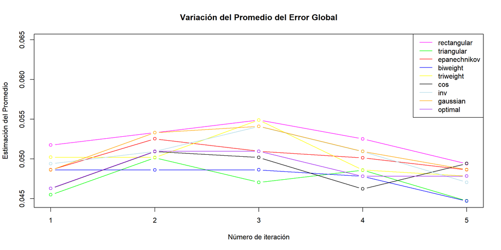

```r
n <- dim(tumores)[1]

## Vamos a generar el modelo dejando un grupo para testing y los demás datos para aprendizaje.
err.pr.1 <- 0
err.pr.2 <- 0
err.pr.3 <- 0
err.pr.4 <- 0
err.pr.5 <- 0
err.pr.6 <- 0
err.pr.7 <- 0
err.pr.8 <- 0
err.pr.9 <- 0

# Hacemos validación cruzada 5 veces para ver que el error se estabiliza
for(i in 1:5) {
  v.err.1 <- 0
  v.err.2<- 0
  v.err.3 <- 0
  v.err.4 <- 0
  v.err.5<- 0
  v.err.6 <- 0
  v.err.7 <- 0
  v.err.8<- 0
  v.err.9 <- 0

  # Esta instrucción genera los k=10 grupos (Folds)
  grupos <- createFolds(1:n,10) # grupos$Fold0i es el i-ésimo grupo
  # Este ciclo es el que hace "cross-validation" (validación cruzada) con 10 grupos (Folds)
  for(k in 1:10) {
      muestra <- grupos[[k]] # Por ser una lista requiere de doble paréntesis
      ttesting <- tumores[muestra,]
      taprendizaje <- tumores[-muestra,]

      modelo.rectangular <- train.knn(tipo~., data = taprendizaje, kernel = "rectangular")
      modelo.triangular <- train.knn(tipo~., data = taprendizaje, kernel = "triangular")
      modelo.epanechnikov <- train.knn(tipo~., data = taprendizaje, kernel = "epanechnikov")
      modelo.biweight <- train.knn(tipo~., data = taprendizaje, kernel = "biweight")
      modelo.triweight <- train.knn(tipo~., data = taprendizaje, kernel = "triweight")
      modelo.cos <- train.knn(tipo~., data = taprendizaje, kernel = "cos")
      modelo.inv <- train.knn(tipo~., data = taprendizaje, kernel = "inv")
      modelo.gaussian <- train.knn(tipo~., data = taprendizaje, kernel = "gaussian")
      modelo.optimal <- train.knn(tipo~., data = taprendizaje, kernel = "optimal")



      prediccion1 <- predict(modelo.rectangular,ttesting,type = "class")
      prediccion2 <- predict(modelo.triangular,ttesting,type = "class")
      prediccion3 <- predict(modelo.epanechnikov,ttesting,type = "class")
      prediccion4 <- predict(modelo.biweight,ttesting,type = "class")
      prediccion5 <- predict(modelo.triweight,ttesting,type = "class")
      prediccion6 <- predict(modelo.cos,ttesting, type = "class")
      prediccion7 <- predict(modelo.inv,ttesting,type = "class")
      prediccion8 <- predict(modelo.gaussian,ttesting,type = "class")
      prediccion9 <- predict(modelo.optimal,ttesting, type = "class")


      MC.1 <- confusion.matrix(ttesting, prediccion1)
      MC.2 <- confusion.matrix(ttesting, prediccion2)
      MC.3 <- confusion.matrix(ttesting, prediccion3)
      MC.4 <- confusion.matrix(ttesting, prediccion4)
      MC.5 <- confusion.matrix(ttesting, prediccion5)
      MC.6 <- confusion.matrix(ttesting, prediccion6)
      MC.7 <- confusion.matrix(ttesting, prediccion7)
      MC.8 <- confusion.matrix(ttesting, prediccion8)
      MC.9 <- confusion.matrix(ttesting, prediccion9)

      #Precisión Global (De todos los valores el porcentaje que predijo bien)
      acierto.1 <- sum(diag(MC.1)/sum(MC.1))
      acierto.2 <- sum(diag(MC.2)/sum(MC.2))
      acierto.3 <- sum(diag(MC.3)/sum(MC.3))
      acierto.4 <- sum(diag(MC.4)/sum(MC.4))
      acierto.5 <- sum(diag(MC.5)/sum(MC.5))
      acierto.6 <- sum(diag(MC.6)/sum(MC.6))
      acierto.7 <- sum(diag(MC.7)/sum(MC.7))
      acierto.8 <- sum(diag(MC.8)/sum(MC.8))
      acierto.9 <- sum(diag(MC.9)/sum(MC.9))


      #error global
      v.err.1[k] <- 1 - acierto.1
      v.err.2[k] <- 1 - acierto.2
      v.err.3[k] <- 1 - acierto.3
      v.err.4[k] <- 1 - acierto.4
      v.err.5[k] <- 1 - acierto.5
      v.err.6[k] <- 1 - acierto.6
      v.err.7[k] <- 1 - acierto.7
      v.err.8[k] <- 1 - acierto.8
      v.err.9[k] <- 1 - acierto.9
  }

  #promedio total del error global para cada iteración
  err.pr.1[i] <- mean(v.err.1)
  err.pr.2[i] <- mean(v.err.2)
  err.pr.3[i] <- mean(v.err.3)
  err.pr.4[i] <- mean(v.err.4)
  err.pr.5[i] <- mean(v.err.5)
  err.pr.6[i] <- mean(v.err.6)
  err.pr.7[i] <- mean(v.err.7)
  err.pr.8[i] <- mean(v.err.8)
  err.pr.9[i] <- mean(v.err.9)



  }


#Gráficos

colores <- c("magenta","green","red","blue","yellow","black","lightblue","orange","purple")
nucleos <- c("rectangular", "triangular", "epanechnikov", "biweight", "triweight", "cos", "inv", "gaussian", "optimal")

error <- c(err.pr.1,err.pr.2,err.pr.3,err.pr.4,err.pr.5,err.pr.6,err.pr.7,err.pr.8,err.pr.9)

names(error)<- nucleos


plot(err.pr.1, col = colores[1], type = "b", ylim = c(min(error), max(error) + 0.01), main = "Variación del Promedio del Error Global", xlab = "Número de iteración", ylab = "Estimación del Promedio")
points(err.pr.2, col = colores[2], type = "b")
points(err.pr.3, col = colores[3], type = "b")
points(err.pr.4, col = colores[4], type = "b")
points(err.pr.5, col = colores[5], type = "b")
points(err.pr.6, col = colores[6], type = "b")
points(err.pr.7, col = colores[7], type = "b")
points(err.pr.8, col = colores[8], type = "b")
points(err.pr.9, col = colores[9], type = "b")
legend("topright", legend = c(nucleos), col = colores, lty = 1, lwd = 1)
```

## 3.

Para estar realmente seguros de cuál de los tipos algoritmos es mejor, modifique (una en uno solo código) los códigos de los dos ejercicios anteriores de manera que, en lugar de sumar la cantidad de 1’s detectados y de promediar los errores globales, guarde en cada iteración (en listas) las matrices de confusión de cada uno de los 3 algoritmos. Luego al final de los ciclos ejecutados para cada algoritmo calcule una Matriz de Confusión Promedio de todas las matrices de confusión guardadas en la lista del respectivo algoritmo; así con estas Matrices de Confusión Promedio, mediante gráficos de barras, determine el método que en promedio detecta mayor porcentaje de 1’s, determine el método que en promedio detecta mayor porcentaje de 0’s y determine el método que en promedio tiene menor error global.

```r
## Vamos a generar el modelo dejando un grupo para testing y los demás datos para aprendizaje.
mc.1 <- 0
mc.2 <- 0
mc.3 <- 0
mc.4 <- 0
mc.5 <- 0
mc.6 <- 0
mc.7 <- 0
mc.8 <- 0
mc.9 <- 0

# Hacemos validación cruzada 5 veces para ver que el error se estabiliza
for(i in 1:5) {
  matrizTotal.1 <- 0
  matrizTotal.2<- 0
  matrizTotal.3 <- 0
  matrizTotal.4 <- 0
  matrizTotal.5<- 0
  matrizTotal.6 <- 0
  matrizTotal.7 <- 0
  matrizTotal.8<- 0
  matrizTotal.9 <- 0

  # Esta instrucción genera los k=10 grupos (Folds)
  grupos <- createFolds(1:n,10) # grupos$Fold0i es el i-ésimo grupo
  # Este ciclo es el que hace "cross-validation" (validación cruzada) con 10 grupos (Folds)
  for(k in 1:10) {
      muestra <- grupos[[k]] # Por ser una lista requiere de doble paréntesis
      ttesting <- tumores[muestra,]
      taprendizaje <- tumores[-muestra,]

      modelo.rectangular <- train.knn(tipo~., data = taprendizaje, kernel = "rectangular")
      modelo.triangular <- train.knn(tipo~., data = taprendizaje, kernel = "triangular")
      modelo.epanechnikov <- train.knn(tipo~., data = taprendizaje, kernel = "epanechnikov")
      modelo.biweight <- train.knn(tipo~., data = taprendizaje, kernel = "biweight")
      modelo.triweight <- train.knn(tipo~., data = taprendizaje, kernel = "triweight")
      modelo.cos <- train.knn(tipo~., data = taprendizaje, kernel = "cos")
      modelo.inv <- train.knn(tipo~., data = taprendizaje, kernel = "inv")
      modelo.gaussian <- train.knn(tipo~., data = taprendizaje, kernel = "gaussian")
      modelo.optimal <- train.knn(tipo~., data = taprendizaje, kernel = "optimal")



      prediccion1 <- predict(modelo.rectangular,ttesting,type = "class")
      prediccion2 <- predict(modelo.triangular,ttesting,type = "class")
      prediccion3 <- predict(modelo.epanechnikov,ttesting,type = "class")
      prediccion4 <- predict(modelo.biweight,ttesting,type = "class")
      prediccion5 <- predict(modelo.triweight,ttesting,type = "class")
      prediccion6 <- predict(modelo.cos,ttesting, type = "class")
      prediccion7 <- predict(modelo.inv,ttesting,type = "class")
      prediccion8 <- predict(modelo.gaussian,ttesting,type = "class")
      prediccion9 <- predict(modelo.optimal,ttesting, type = "class")


      MC.1 <- confusion.matrix(ttesting, prediccion1)
      MC.2 <- confusion.matrix(ttesting, prediccion2)
      MC.3 <- confusion.matrix(ttesting, prediccion3)
      MC.4 <- confusion.matrix(ttesting, prediccion4)
      MC.5 <- confusion.matrix(ttesting, prediccion5)
      MC.6 <- confusion.matrix(ttesting, prediccion6)
      MC.7 <- confusion.matrix(ttesting, prediccion7)
      MC.8 <- confusion.matrix(ttesting, prediccion8)
      MC.9 <- confusion.matrix(ttesting, prediccion9)

      matrizTotal.1 <- matrizTotal.1 + MC.1
      matrizTotal.2<- matrizTotal.2 + MC.2
      matrizTotal.3 <- matrizTotal.3 + MC.3
      matrizTotal.4 <- matrizTotal.4 + MC.4
      matrizTotal.5<- matrizTotal.5 + MC.5
      matrizTotal.6 <- matrizTotal.6 + MC.6
      matrizTotal.7 <- matrizTotal.7 + MC.7
      matrizTotal.8<- matrizTotal.8 + MC.8
      matrizTotal.9 <- matrizTotal.9 + MC.9

  }

  #Matriz Total para cada iteración

  mc.1 <- mc.1 + matrizTotal.1
  mc.2 <- mc.2 + matrizTotal.2
  mc.3 <- mc.3 + matrizTotal.3
  mc.4 <- mc.4 + matrizTotal.4
  mc.5 <- mc.5 + matrizTotal.5
  mc.6 <- mc.6 + matrizTotal.6
  mc.7 <- mc.7 + matrizTotal.7
  mc.8 <- mc.8 + matrizTotal.8
  mc.9 <- mc.9 + matrizTotal.9
}

#Matriz de Confusion Promedio

mc.pr.1 <- mc.1/5
mc.pr.2 <- mc.2/5
mc.pr.3 <- mc.3/5
mc.pr.4 <- mc.4/5
mc.pr.5 <- mc.5/5
mc.pr.6 <- mc.6/5
mc.pr.7 <- mc.7/5
mc.pr.8 <- mc.8/5
mc.pr.9 <- mc.9/5


#Error global Promedio
err.pr.1 <- 1-  sum(diag(mc.pr.1)/sum(mc.pr.1))
err.pr.2 <- 1- sum(diag(mc.pr.2)/sum(mc.pr.2))
err.pr.3 <- 1 -sum(diag(mc.pr.3)/sum(mc.pr.3))
err.pr.4 <- 1-  sum(diag(mc.pr.4)/sum(mc.pr.4))
err.pr.5 <- 1- sum(diag(mc.pr.5)/sum(mc.pr.5))
err.pr.6 <- 1 -sum(diag(mc.pr.6)/sum(mc.pr.6))
err.pr.7 <- 1-  sum(diag(mc.pr.7)/sum(mc.pr.7))
err.pr.8 <- 1- sum(diag(mc.pr.8)/sum(mc.pr.8))
err.pr.9 <- 1 -sum(diag(mc.pr.9)/sum(mc.pr.9))
```

Graficos

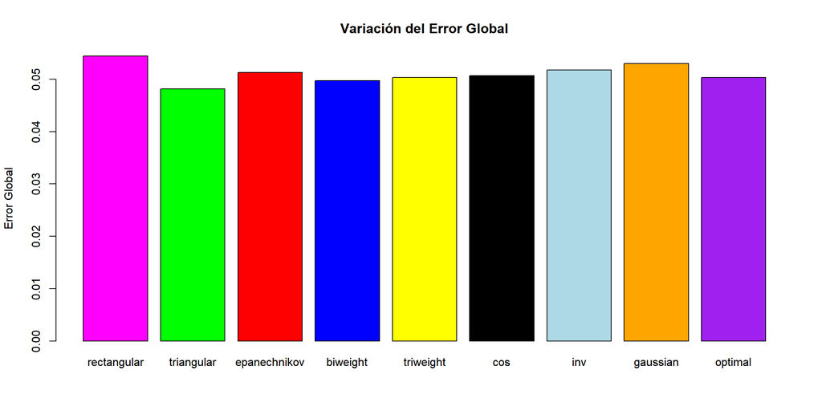

```r
errorPr <- c(err.pr.1,err.pr.2,err.pr.3,err.pr.4,err.pr.5,err.pr.6,err.pr.7,err.pr.8,err.pr.9)
names(errorPr) <- nucleos

barplot(errorPr, ylim = c(0,max(errorPr)), main = "Variación del Error Global", ylab = "Error Global", col = colores)
```

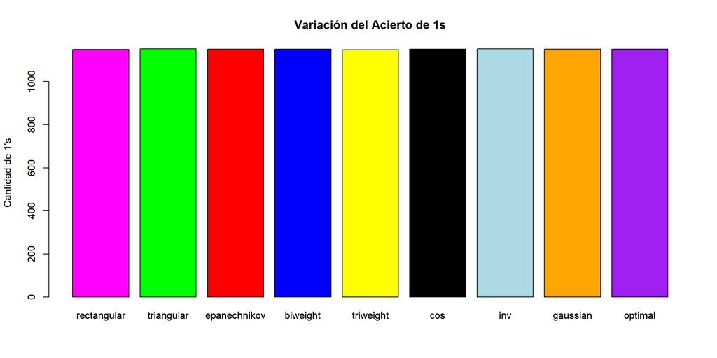

```r
cantidad1 <- c(mc.pr.1[4],mc.pr.2[4],mc.pr.3[4],mc.pr.4[4],mc.pr.5[4],mc.pr.6[4],mc.pr.7[4],mc.pr.8[4],mc.pr.9[4])
names(cantidad1)<- nucleos

barplot(cantidad1, ylim = c(0,max(cantidad1)), main = "Variación del Acierto de 1s", ylab = "Cantidad de 1's", col = colores)
```

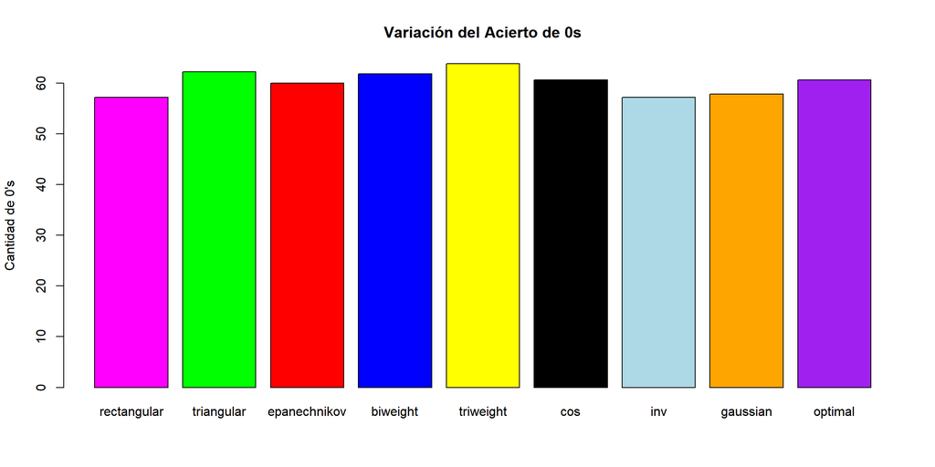

```r
cantidad0 <- c(mc.pr.1[1],mc.pr.2[1],mc.pr.3[1],mc.pr.4[1],mc.pr.5[1],mc.pr.6[1],mc.pr.7[1],mc.pr.8[1],mc.pr.9[1])
names(cantidad0)<- nucleos

barplot(cantidad0, ylim = c(0,max(cantidad0)), main = "Variación del Acierto de 0s", ylab = "Cantidad de 0's", col = colores)
```

Seg’un los graficos anteriores el error minimo global en promedio lo tiene el nucleo triangular y parece que en numero de aciertos todos son bastante similares en 1, sin embargo para el 0 el mayor numero de aciertos se lo gana triweigth.

## 4.

Cu’al algoritmo usar’ia con base en la informacion obtenida en el ejercicio anterior?

```r
#minimo error
errorPr[errorPr == min(errorPr)]
```

```
triangular
0.04815686
```

```r
#maximo cantidad de 1s predichos
cantidad1[cantidad1 == max(cantidad1)]
```

```
   inv
1151.8
```

```r
#maximo cantidad de 0s predichos
cantidad0[cantidad0 == max(cantidad0)]
```

```
triweight
     63.8
```

# Ejercicio 4 : [25 puntos]

Esta pregunta también utilizan nuevamente los datos tumores.csv.

## 1.

El objetivo de este ejercicio es comparar todos los métodos predictivos vistos en el curso con esta tabla de datos. Aquí interesa predecir en la variable tipo, para esto genere 5 Validaciones Cruzadas con 10 grupos para los métodos SVM, KNN, Árboles, Bosques, Potenciación, eXtreme Gradient Boosting, LDA, Bayes, Regresión Logística, ConsensoPropio y Redes Neuronales, para KNN y Potenciación use los parámetros obtenidos en las calibraciones realizadas en los ejercicios anteriores. Luego grafique las 5 iteraciones para todos los métodos en el mismo gráfico. ¿Se puede determinar con claridad cuál métodos es el mejor?

### Validación Cruzada

```r
library(MASS)

v.error.svm <- rep(0,5)
v.error.arb <- rep(0,5)
v.error.rForest<- rep(0,5)
v.error.xg <- rep(0,5)
v.error.lda <- rep(0,5)
v.error.bayes <- rep(0,5)
v.error.nnet <- rep(0,5)
v.error.pot <- rep(0,5)

#Hacemos validación cruzada 5 veces
for (i in 1:5) {
  errori.svm <- 0
  errori.rpart <- 0
  errori.rForest <- 0
  errori.xg <- 0
  errori.lda <- 0
  errori.bayes <- 0
  errori.nnet <- 0
  errori.pot <- 0

  #se generan los 10 grupos
  grupos <- createFolds(1:n,10)

  #ciclo que empieza a hacer validación cruzada con 10 grupos
  for (k in 1:10) {

    muestra <- grupos[[k]]
    ttesting <- tumores[muestra,]
    taprendizaje <- tumores[-muestra,]

    modelo.svm <- train.svm(tipo~., taprendizaje)
    modelo.rpart <- train.rpart(tipo~., taprendizaje)
    modelo.rForest <- train.randomForest(tipo~., taprendizaje)
    modelo.xg <- train.xgboost(tipo~.,taprendizaje, nrounds = 500,verbose = F)
    modelo.lda <- lda(tipo~., taprendizaje)
    modelo.bayes <- train.bayes(tipo~.,taprendizaje)
    modelo.nnet <- train.nnet(tipo~.,taprendizaje, size =2,maxit=1000)
    modelo.pot <- train.ada(tipo~.,data=taprendizaje,iter=80,nu=1,type="real")


    prediccion.svm <- predict(modelo.svm, ttesting)
    prediccion.rpart <- predict(modelo.rpart, ttesting)
    prediccion.rForest <- predict(modelo.rForest, ttesting)
    prediccion.xg <- predict(modelo.xg, ttesting)
    prediccion.lda <- predict(modelo.lda, ttesting)
    prediccion.bayes <- predict(modelo.bayes, ttesting)
    prediccion.nnet <- predict(modelo.nnet, ttesting)
    prediccion.pot <- predict(modelo.pot, ttesting)

    MC.svm <- confusion.matrix(ttesting, prediccion.svm)
    MC.rpart <- confusion.matrix(ttesting, prediccion.rpart)
    MC.rForest <- confusion.matrix(ttesting, prediccion.rForest)
    MC.xg <- confusion.matrix(ttesting, prediccion.xg)
    MC.lda <- table(ttesting[,17], prediccion.lda$class)
    MC.bayes <- confusion.matrix(ttesting, prediccion.bayes)
    MC.nnet <- confusion.matrix(ttesting, prediccion.nnet)
    MC.pot <- confusion.matrix(ttesting,prediccion.pot)

    #error
    error.svm <- 1 - sum(diag(MC.svm))/sum(MC.svm)
    error.rpart <- 1 - sum(diag(MC.rpart))/sum(MC.rpart)
    error.rForest <- 1 - sum(diag(MC.rForest))/sum(MC.rForest)
    error.xg <- 1 - sum(diag(MC.xg))/sum(MC.xg)
    error.lda <- 1 - sum(diag(MC.lda))/sum(MC.lda)
    error.bayes <- 1 - sum(diag(MC.bayes))/sum(MC.bayes)
    error.nnet <- 1 - sum(diag(MC.nnet))/sum(MC.nnet)
    error.pot <- 1 - sum(diag(MC.pot))/sum(MC.pot)

    #suma los errores de cada grupo
    errori.svm <- errori.svm + error.svm
    errori.rpart <- errori.rpart + error.rpart
    errori.rForest <- errori.rForest + error.rForest
    errori.xg <- errori.xg + error.xg
    errori.lda <- errori.lda+ error.lda
    errori.bayes <- errori.bayes + error.bayes
    errori.nnet <- errori.nnet + error.nnet
    errori.pot <- errori.pot + error.pot


  }
  #promedia el error
  v.error.svm[i]  <- errori.svm/10
  v.error.arb[i]  <- errori.rpart/10
  v.error.rForest[i]  <- errori.rForest/10
  v.error.xg[i]  <- errori.xg/10
  v.error.lda[i]  <- errori.lda/10
  v.error.bayes[i]  <- errori.bayes/10
  v.error.nnet[i]  <- errori.nnet/10
  v.error.pot[i] <- errori.pot/10

}
```

### Gráficos

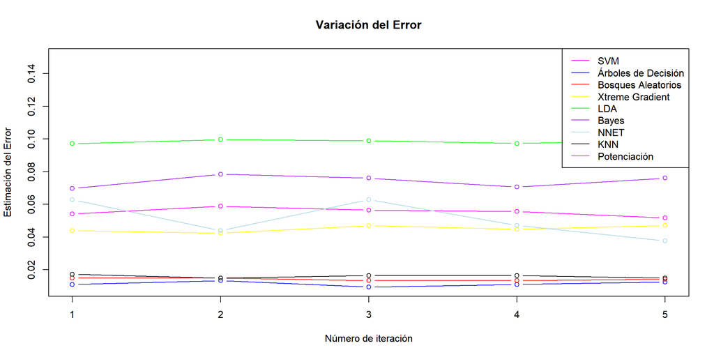

```r
errores <- c(v.error.svm,v.error.arb,v.error.rForest,v.error.xg,v.error.lda,v.error.bayes, v.error.nnet, v.error.pot)

v.error.knn <- v.error.tt


plot(v.error.svm, col = "magenta",
     type = "b",
     main = "Variación del Error", xlab = "Número de iteración",
     ylab = "Estimación del Error", ylim = c(min(errores), max(errores) + 0.05))
points(v.error.rForest, col = "blue", type = "b")
points(v.error.xg, col = "red", type = "b")
points(v.error.lda, col = "yellow", type = "b")
points(v.error.bayes, col = "green", type = "b")
points(v.error.nnet, col = "purple", type = "b")
points(v.error.knn, col = "lightblue", type = "b")
points(v.error.pot, col = "black", type = "b")
legend("topright", legend = c("SVM","Árboles de Decisión","Bosques Aleatorios","Xtreme Gradient","LDA","Bayes","NNET","KNN","Potenciación"), col = c("magenta",
    "blue","red","yellow","green","purple","lightblue","black"), lty = 1, lwd = 1)
```

## 2.

Para estar realmente seguros de cuál de los métodos es mejor, modifique (una en uno solo código) los códigos de los dos ejercicios anteriores de manera que, en lugar de sumar la cantidad de 1’s detectados y de promediar los errores globales, guarde en cada iteración (en listas) las matrices de confusión de cada uno de los 11 métodos. Luego al final de los ciclos ejecutados para cada algoritmo calcule una Matriz de Confusión Promedio de todas las matrices de confusión guardadas en la lista del respectivo algoritmo; así con estas Matrices de Confusión Promedio, mediante gráficos de barras, determine el método que en promedio detecta mayor porcentaje de 1’s, determine el método que en promedio detecta mayor porcentaje de 0’s y determine el método que en promedio tiene menor error global.

### Matrices Promedio

```r
n <- dim(tumores)[1]

## Vamos a generar el modelo dejando un grupo para testing y los demás datos para aprendizaje.
mc.svm <- 0
mc.arb <- 0
mc.rForest<- 0
mc.xg <- 0
mc.lda <- 0
mc.bayes <- 0
mc.nnet <- 0
mc.pot <- 0
mc.knn <- 0

# Hacemos validación cruzada 5 veces para ver que el error se estabiliza
for(i in 1:5) {

   matrizTotal.svm <- 0
   matrizTotal.rpart<- 0
   matrizTotal.rForest <- 0
   matrizTotal.xg <- 0
   matrizTotal.lda <- 0
   matrizTotal.bayes <- 0
   matrizTotal.nnet <- 0
   matrizTotal.knn <- 0
   matrizTotal.pot <- 0

  # Esta instrucción genera los k=10 grupos (Folds)
  grupos <- createFolds(1:n,10) # grupos$Fold0i es el i-ésimo grupo
  # Este ciclo es el que hace "cross-validation" (validación cruzada) con 10 grupos (Folds)
  for(k in 1:10) {
      muestra <- grupos[[k]] # Por ser una lista requiere de doble paréntesis
      ttesting <- tumores[muestra,]
      taprendizaje <- tumores[-muestra,]

      modelo.svm <- train.svm(tipo~., taprendizaje)
      modelo.rpart <- train.rpart(tipo~., taprendizaje)
      modelo.rForest <- train.randomForest(tipo~., taprendizaje)
      modelo.xg <- train.xgboost(tipo~.,taprendizaje, nrounds = 500,verbose = 0)
      modelo.lda <- lda(tipo~., taprendizaje)
      modelo.bayes <- train.bayes(tipo~.,taprendizaje)
      modelo.nnet <- train.nnet(tipo~.,taprendizaje, size =2,maxit=1000)
      modelo.knn <- train.knn(tipo~.,taprendizaje, kmax = 50)
      modelo.pot <- train.ada(tipo~.,data=taprendizaje,iter=80,nu=1,type="real")


      prediccion.svm <- predict(modelo.svm, ttesting)
      prediccion.rpart <- predict(modelo.rpart, ttesting)
      prediccion.rForest <- predict(modelo.rForest, ttesting)
      prediccion.xg <- predict(modelo.xg, ttesting)
      prediccion.lda <- predict(modelo.lda, ttesting)
      prediccion.bayes <- predict(modelo.bayes, ttesting)
      prediccion.nnet <- predict(modelo.nnet, ttesting)
      prediccion.knn <- predict(modelo, ttesting)
      prediccion.pot <- predict(modelo.pot, ttesting)

      MC.svm <- confusion.matrix(ttesting, prediccion.svm)
      MC.rpart <- confusion.matrix(ttesting, prediccion.rpart)
      MC.rForest <- confusion.matrix(ttesting, prediccion.rForest)
      MC.xg <- confusion.matrix(ttesting, prediccion.xg)
      MC.lda <- table(ttesting[,17], prediccion.lda$class)
      MC.bayes <- confusion.matrix(ttesting, prediccion.bayes)
      MC.nnet <- confusion.matrix(ttesting, prediccion.nnet)
      MC.knn <- confusion.matrix(ttesting,prediccion.knn)
      MC.pot <- confusion.matrix(ttesting,prediccion.pot)



      # Sumatoria de todas las matrices de confusión

      matrizTotal.svm <- matrizTotal.svm + MC.svm
      matrizTotal.rpart<- matrizTotal.rpart + MC.rpart
      matrizTotal.rForest <- matrizTotal.rForest + MC.rForest
      matrizTotal.xg <- matrizTotal.xg + MC.xg
      matrizTotal.lda <- matrizTotal.lda + MC.lda
      matrizTotal.bayes <- matrizTotal.bayes + MC.bayes
      matrizTotal.nnet <- matrizTotal.nnet + MC.nnet
      matrizTotal.knn <- matrizTotal.knn + MC.knn
      matrizTotal.pot <- matrizTotal.pot + MC.pot

  }

  #Matriz Total para cada iteración
  mc.svm <- mc.svm + matrizTotal.svm
  mc.arb <- mc.arb + matrizTotal.rpart
  mc.rForest<- mc.rForest + matrizTotal.rForest
  mc.xg <- mc.xg + matrizTotal.xg
  mc.lda <- mc.lda + matrizTotal.lda
  mc.bayes <- mc.bayes + matrizTotal.bayes
  mc.nnet <- mc.nnet + matrizTotal.nnet
  mc.pot <- mc.pot + matrizTotal.knn
  mc.knn <- mc.knn + matrizTotal.pot

}
#Matriz de Confusion Promedio

  mc.pr.svm <- mc.svm/5
  mc.pr.arb <- mc.arb/5
  mc.pr.rForest <- mc.rForest/5
  mc.pr.xg <- mc.xg /5
  mc.pr.lda <- mc.lda /5
  mc.pr.bayes <- mc.bayes /5
  mc.pr.nnet <- mc.nnet/5
  mc.pr.pot <- mc.pot/5
  mc.pr.knn <- mc.knn /5


#Error global Promedio
err.pr.svm <- 1-  sum(diag(mc.pr.svm)/sum(mc.pr.svm))
err.pr.arb <- 1- sum(diag(mc.pr.arb)/sum(mc.pr.arb))
err.pr.rForest <- 1 -sum(diag(mc.pr.rForest)/sum(mc.pr.rForest))
err.pr.xg <- 1-  sum(diag(mc.pr.xg)/sum(mc.pr.xg))
err.pr.lda <- 1- sum(diag(mc.pr.lda)/sum(mc.pr.lda))
err.pr.bayes <- 1 -sum(diag(mc.pr.bayes)/sum(mc.pr.bayes))
err.pr.nnet <- 1-  sum(diag(mc.pr.nnet)/sum(mc.pr.nnet))
err.pr.pot <- 1- sum(diag(mc.pr.pot)/sum(mc.pr.pot))
err.pr.knn <- 1 -sum(diag(mc.pr.knn)/sum(mc.pr.knn))
```

### Gráficos

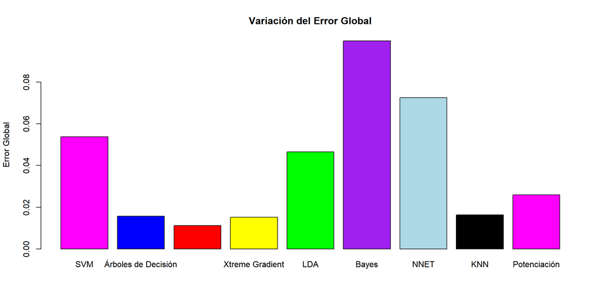

```r
error <- c(err.pr.svm, err.pr.arb, err.pr.rForest, err.pr.xg, err.pr.lda,
err.pr.bayes, err.pr.nnet, err.pr.knn, err.pr.pot)
names(error) <- c("SVM","Árboles de Decisión","Bosques Aleatorios","Xtreme Gradient","LDA","Bayes","NNET","KNN","Potenciación")

cantidad.1 <- c(mc.pr.svm[4],mc.pr.arb[4],mc.pr.rForest[4],mc.pr.xg[4],mc.pr.lda[4],mc.pr.bayes[4], mc.pr.nnet[4], mc.pr.knn[4], mc.pr.pot[4])

names(cantidad.1) <- c("SVM","Árboles de Decisión","Bosques Aleatorios","Xtreme Gradient","LDA","Bayes","NNET","KNN","Potenciación")

cantidad.0 <- c(mc.pr.svm[1],mc.pr.arb[1],mc.pr.rForest[1],mc.pr.xg[1],mc.pr.lda[1],mc.pr.bayes[1], mc.pr.nnet[1], mc.pr.knn[1], mc.pr.pot[1])

names(cantidad.0) <- c("SVM","Árboles de Decisión","Bosques Aleatorios","Xtreme Gradient","LDA","Bayes","NNET","KNN","Potenciación")



barplot(error, ylim = c(0,max(error)), main = "Variación del Error Global", ylab = "Error Global", col = c("magenta",
    "blue","red","yellow","green","purple","lightblue","black"))
```

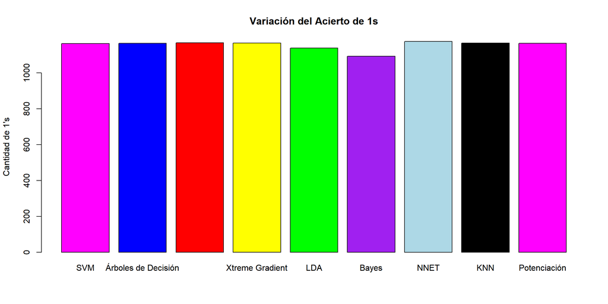

```r
barplot(cantidad.1, ylim = c(0,max(cantidad.1)), main = "Variación del Acierto de 1s", ylab = "Cantidad de 1's",col = c("magenta",
    "blue","red","yellow","green","purple","lightblue","black"))
```

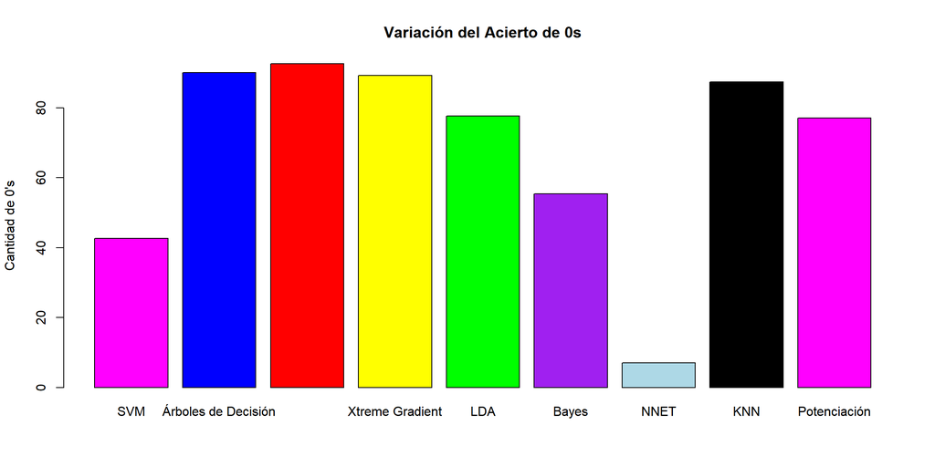

```r
barplot(cantidad.0, ylim = c(0,max(cantidad.0)), main = "Variación del Acierto de 0s", ylab = "Cantidad de 0's", col = c("magenta",
    "blue","red","yellow","green","purple","lightblue","black"))
```

## 4. ¿Cuál algoritmo usaría con base en la información obtenida en el ejercicio anterior?

```r
#minimo error
error[error == min(error)]
```

```
Bosques Aleatorios
        0.01113725
```

```r
#maximo cantidad de 1s predichos
cantidad.1[cantidad.1 == max(cantidad.1)]
```

```
  NNET
1175.6
```

```r
#maximo cantidad de 0s predichos
cantidad.0[cantidad.0 == max(cantidad.0)]
```

```
Bosques Aleatorios
              92.6
```